# Analysis on Impact of Storms and Severe Weather Events on Health and Economy

Joanna Teo

Sunday, December 21, 2014

## Synopsis

Storms and other severe weather events can cause both public health and economic problems for communities and municipalities. Many severe events can result in fatalities, injuries, and property damage, and preventing such outcomes to the extent possible is a key concern.

This project involves exploring the U.S. National Oceanic and Atmospheric Administration’s (NOAA) storm database. This database tracks characteristics of major storms and weather events in the United States, including when and where they occur, as well as estimates of any fatalities, injuries, and property damage. The data was collected during the period from 1950 and November 2011.

This report analyses NOAA storm database and address the following questions:

Across the United States, which types of events (as indicated in the EVTYPE variable) are most harmful with respect to population health? Across the United States, which types of events have the greatest economic consequences?

The purpose of this analysis is to find out which weather events are the most harmful on health and economy. From the analysis below, We conclude that tornadoes have the most harmful impact on health in both injuries and fatalities. As for impact on economy consequences, floods were the most harmful, mostly due to property damage.

## Data Processing

#### Loading the data

The dataset can be downloaded from this link: https://d396qusza40orc.cloudfront.net/repdata%2Fdata%2FStormData.csv.bz2

```r
knitr::opts_chunk$set(echo=TRUE, fig.width=16, fig.height=6)
setwd("C:/Users/jteo/Desktop/coursera/repdata-016-assignment2")
```

#### Loading the required libraries.

```r
library(ggplot2)
library(plyr)
library(gridExtra)
```

#### Downloading data files.

```r
if (!file.exists("repdata-data-StormData.csv")) {
download.file("http://d396qusza40orc.cloudfront.net/repdata%2Fdata%2FStormData.csv.bz2", "repdata-data-StormData.csv.bz2")
        dateDownloaded=date()
        bunzip2(file="repdata-data-StormData.csv.bz2",destname="repdata-data-StormData.csv")
#         unlink("repdata-data-StormData.csv.bz2")
}
```

#### Reading the data.

```r
stormdata<-read.csv("repdata-data-StormData.csv")
```

#### Examining the data.

```r
dim(stormdata)
```

```
## [1] 902297     37
```

The storm data set has 902297 rows and 37 columns.

We are keen to find out the type of events that cause the most damage to the population health and economy in this analysis. Thus, the columns of interest that we will look at are the “EVTYPE”, “PROPDMG”, “PROPDMGEXP”, “FATALITIES”, “INJURIES”, “CROPDMG”, “CROPDMGEXP” columns. We will start by extracting the subset of the data limited to these variables.

SOme data clean up will be performed to remove the “Summary” event types in the data set. The same names treated differently to eliminate redundancy. EVTYPE and PROPDMGEXP and CROPDMGEXP variable values will also be converted to upper case for consistency.

#### Data cleaning

```r
impactdata<-stormdata[, c("EVTYPE", "PROPDMG", "PROPDMGEXP", "FATALITIES", "INJURIES", "CROPDMG", "CROPDMGEXP")]
impactdata<-impactdata[!grepl("Summary", impactdata$EVTYPE),]
impactdata$EVTYPE<-as.factor(toupper(impactdata$EVTYPE))
impactdata$PROPDMGEXP<-as.factor(toupper(impactdata$PROPDMGEXP))
impactdata$CROPDMGEXP<-as.factor(toupper(impactdata$CROPDMGEXP))

dim(impactdata)
```

```
## [1] 902224      7
```

The impactdata dataset now has 902224 rows and 7 columns.

```r
head(impactdata, n=5)
```

```
##    EVTYPE PROPDMG PROPDMGEXP FATALITIES INJURIES CROPDMG CROPDMGEXP
## 1 TORNADO    25.0          K          0       15       0
## 2 TORNADO     2.5          K          0        0       0
## 3 TORNADO    25.0          K          0        2       0
## 4 TORNADO     2.5          K          0        2       0
## 5 TORNADO     2.5          K          0        2       0
```

The total dollar amounts for property damage and crop damage will need to be calculated. We will multiply the PROPDMGEXP values with the PROPDMG values, as well as the CROPDMGEXP values with the CROPDMG values for total property damages and crop damages by event respectively. However, as can be seen by summarising the PROPDMGEXP and CROPDMGEXP variables, the values in both the PROPDMGEXP and CROPDMGEXP are inconsistent and alpha-numeric.

```r
summary(impactdata$PROPDMGEXP)
```

```
##             -      ?      +      0      1      2      3      4      5
## 465861      1      8      5    216     25     13      4      4     28
##      6      7      8      B      H      K      M
##      4      5      1     40      7 424665  11337
```

```r
summary(impactdata$CROPDMGEXP)
```

```
##             ?      0      2      B      K      M
## 618340      7     19      1      9 281853   1995
```

#### The need to standardise values

The documentation does not specify the mapping values for the numeric elements 1:8, as well as the “-”, “?” and “+” in both the PROPDMGEXP and CROPDMGEXP columns

It states that the “B”, “M”, “K”, “H” are exponent values that represent a Billion, Million, Thousand and Hundred respectively. Moreover, property and crop damage amounts can be computed by multiplying the PROPDMGEXP values with the PROPDMG values. Before we can do that, there is some clean up required. The “B”, “M”, “K”, “H” have to be replaced with the appropriate exponent values and the rest of the levels that are undefined have to be addressed.

Out of a total row count in excess of 900,000, which is less than 0.001%, there are only 8 rows containing ‘?’ and ‘2’ in the CROPDMGEXP variable. Therefore we can conclude that setting them to NA will have a negligible effect. Let us take a look at the proportion of levels that are defined out of the total number of rows in the PROPDMGEXP variable.

```r
sum(impactdata$PROPDMGEXP %in% c("", "0", "B", "H", "M", "K")) / nrow(impactdata)
```

```
## [1] 0.9998914
```

From here, we observe that defined values takes up 99.9% of the PROPDMGEXP dataset. What this means is that spending time to determine what the undefined values meant or represent will not make any significant impact to the rest of the analysis. These undefined values are thus set as NA. the exponent letter indicators are being replaced by the actual numeric value, the column is converted to a numeric variable, the damages are computed and two new variables are added to the impactdata dataset, containing the property and crop damage values.

```r
prop<-as.character(impactdata$PROPDMGEXP)
prop[prop %in% c("?","-","+","1","2","3","4","5","6","7","8")]<-NA
prop[prop %in% c("","0")]<-0
prop<-gsub("B", 10^9, prop)
prop<-gsub("K", 1000, prop)
prop<-gsub("H", 100, prop)
prop<-gsub("M", 10^6, prop)
impactdata$PROPDMGEXP<-as.numeric(prop)
impactdata$TOTALPROPDMG<-impactdata$PROPDMGEXP*impactdata$PROPDMG

crop<-as.character(impactdata$CROPDMGEXP)
crop[crop %in% c("?","2")]<-NA
crop[crop %in% c("","0")]<-0
crop<-gsub("B", 10^9, crop)
crop<-gsub("K", 1000, crop)
crop<-gsub("M", 10^6, crop)
impactdata$CROPDMGEXP<-as.numeric(crop)
impactdata$TOTALCROPDMG<-impactdata$CROPDMGEXP*impactdata$CROPDMG
```

This new dataset, impactdata, has been cleaned, transformed and ready for additional processing to address the computation of health and economic impact of the storms and other severe weather events.

For the final data processing step, we will create a new dataset by transforming the processed data, impactdata, using the plyr library function ddply, to slice the data by the EVTYPE, to contain the sum of the total fatalities, injuries, property and crop related damages.

All this steps are necessary to address the four requirements - the total fatalities, injuries, property and crop damages. The ddply call below transforms the impactdata dataset to compute the five totals - fatalities, injuries, property damages, crop damages, and the sum of property and crop damages - for each of the event types.

```r
totalImpactdata<-ddply(impactdata, .(EVTYPE), summarize, totalFatal=sum(FATALITIES), totalInjured=sum(INJURIES), totalPropDmg=sum(TOTALPROPDMG), totalCropDmg=sum(TOTALCROPDMG), totalDamages=sum(totalPropDmg,totalCropDmg))
```

## RESULTS:

#### Question 1

WIth the totalImpactdata, we will extract the top ten storms and severe weather event types causing the maximum adverse impact on health - maximum fatalities and injuries.

```r
fataldata<-totalImpactdata[ order(-totalImpactdata[, 2]), ][1:10, ]
injurdata<-totalImpactdata[ order(-totalImpactdata[,3]), ][1:10, ]
```

The top ten fatalities causing events are:

```r
print(fataldata[,1:2], row.names=FALSE)
```

```
##          EVTYPE totalFatal
##         TORNADO       5633
##  EXCESSIVE HEAT       1903
##     FLASH FLOOD        978
##            HEAT        937
##       LIGHTNING        816
##       TSTM WIND        504
##           FLOOD        470
##     RIP CURRENT        368
##       HIGH WIND        248
##       AVALANCHE        224
```

The top ten injuries causing events are:

```r
print(injurdata[,c(1,3)], row.names=FALSE)
```

```
##             EVTYPE totalInjured
##            TORNADO        91346
##          TSTM WIND         6957
##              FLOOD         6789
##     EXCESSIVE HEAT         6525
##          LIGHTNING         5230
##               HEAT         2100
##          ICE STORM         1975
##        FLASH FLOOD         1777
##  THUNDERSTORM WIND         1488
##               HAIL         1361
```

From the top ten storm and severe weather events causing the highest number of fatalities and injuries that Tornados, by far, were the leading cause of both fatalities and injuries across the USA. This is followed by Excessive Heat for fatalities and Thunderstorm wind for injuries.

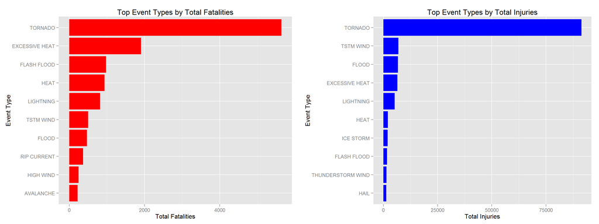

```r
g1<-ggplot(data = fataldata, aes(y=totalFatal,
                x=reorder(EVTYPE, totalFatal))) +
        geom_bar(stat="identity", fill="red") +coord_flip()+
        ylab("Total Fatalities")+
        xlab("Event Type")+
        ggtitle("Top Event Types by Total Fatalities")

g2<-ggplot(data = injurdata, aes(y=totalInjured,
                             x=reorder(EVTYPE, totalInjured))) +
        geom_bar(stat="identity", fill="blue")+ coord_flip()+
        ylab("Total Injuries")+
        xlab("Event Type") +
        ggtitle("Top Event Types by Total Injuries")
grid.arrange(g1,g2, ncol=2)
```

Next we look at the impact of storms and severe weather events on the economy by extracting the top ten events causing the highest amount of property and crop damages.

```r
propdmgdata<-totalImpactdata[ order(-totalImpactdata[, 4]), ][1:10, ]
cropdmgdata<-totalImpactdata[ order(-totalImpactdata[,5]), ][1:10, ]
totalEconImpact<-totalImpactdata[ order(-totalImpactdata[,6]), ][1:10, ]
```

The top ten events that caused the maximum property damage are:

```r
print(propdmgdata[,c(1,4)], row.names=FALSE)
```

```
##             EVTYPE totalPropDmg
##              FLOOD 144657709800
##  HURRICANE/TYPHOON  69305840000
##        STORM SURGE  43323536000
##          HURRICANE  11868319010
##     TROPICAL STORM   7703890550
##       WINTER STORM   6688497250
##        RIVER FLOOD   5118945500
##           WILDFIRE   4765114000
##   STORM SURGE/TIDE   4641188000
##          TSTM WIND   4484958440
```

The top ten events that caused the maximum crop damage are:

```r
print(cropdmgdata[,c(1,5)], row.names=FALSE)
```

```
##             EVTYPE totalCropDmg
##            DROUGHT  13972566000
##              FLOOD   5661968450
##        RIVER FLOOD   5029459000
##          ICE STORM   5022113500
##               HAIL   3025954450
##          HURRICANE   2741910000
##  HURRICANE/TYPHOON   2607872800
##        FLASH FLOOD   1421317100
##       EXTREME COLD   1312973000
##       FROST/FREEZE   1094186000
```

#### Queestion 2

The plot below shows the events that caused the maximum combined economic impact (the sum of property and crop damages) in the USA.

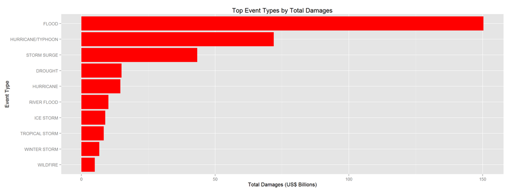

```r
ggplot(data = totalEconImpact, aes(y=totalDamages/10^9, x=reorder(EVTYPE, totalDamages))) +
        geom_bar(stat="identity", fill="red") +coord_flip()+
        ylab("Total Damages (US$ Billions)")+
        xlab("Event Type")+
        ggtitle("Top Event Types by Total Damages")
```

#### Additional Analysis - Not generating plots as this assignment’s aim is to keep below 3 plots.

```r
#
#g3<-ggplot(data = propdmgdata, aes(y=totalPropDmg/10^9, x=reorder(EVTYPE, totalPropDmg))) +
#        geom_bar(stat="identity", fill="red") +coord_flip()+
#        ylab("Total Property Damages (US$ Billions)")+
#        xlab("Event Type")+
#        ggtitle("Top Event Types by Total Property Damages")
#g4<-ggplot(data = cropdmgdata, aes(y=totalCropDmg/10^9, x=reorder(EVTYPE, totalCropDmg))) +
#        geom_bar(stat="identity", fill="red") +coord_flip()+
#        ylab("Total Crop Damages (US$ Billions)")+
#        xlab("Event Type")+
#        ggtitle("Top Event Types by Total Crop Damages")
#grid.arrange(g3, g4, ncol=2)
```